# Housing Research

Roo Fernando

2024-09-18

Last modified: 2025-01-23

## Summary

The methodology of price forecasting is interesting on its own, when applied to housing data it tends to perk a few ears. This article focuses on developing multiple models, regime analysis, and weighted ensembles taking into account historical performance within regimes. This project is inspired by the phrase “wisdom of the crowd”, which essentially says that a collective groups aggregate opinions, predictions, judgement etc. tend to be more accurate than one particular member. We draw an analogy to this phrase in model forecasting, hence developing individual models with a common target variable and taking the aggregate forecast. Going a step further we create a dynamically weighted forecast which weights the models based on historical model performance within regimes. This conceptually makes sense as if we were out at trivia night with 5 friends (all whom have different specialties) though we would all have an answer to the trivia question within our group, the answer we go with would likely be weighted in favor of the friend whose field of expertise overlaps the topic of the question.

## The Data

For housing we use the data available from RedFin’s data center. We focus on Washington County in Oregon because that is where I grew up and I have further research in that particular area due to Intel’s recent struggles (Intel employees roughly 25,000 people in WA County and surrounding counties). The RedFin data consists of the features available as shown below, with the target variable being Median Sale Price for the county. A correlation plot is shown of the feature data as well.

```
## Names of Features and Target variable
```

```
## Region
## Month of Period End
## Median Sale Price **** Target Variable****
## Median Sale Price MoM
## Median Sale Price YoY
## Homes Sold
## Homes Sold MoM
## Homes Sold YoY
## New Listings
## New Listings MoM
## New Listings YoY
## Inventory
## Inventory MoM
##  Inventory YoY
## Days on Market
## Days on Market MoM
## Days on Market YoY
## Average Sale To List
## Average Sale To List MoM
## Average Sale To List YoY
```

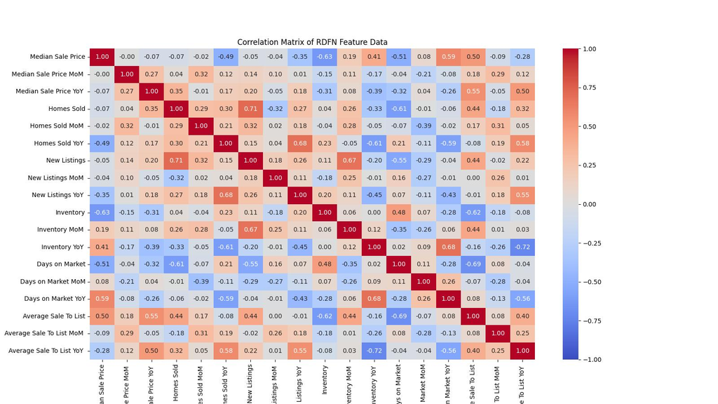

For the regime analysis we use some common indicators from FRED. Having talked to portfolio managers in the financial industry it seems that keeping the dataset simple when identifying regimes is not too far from what is actually practiced in the industry. We will be using Federal Funds Rate, Housing Starts, Unemployment Rate, and CPI all matching the RedFin frequency of monthly. We get rid of look ahead bias by lagging the macro data by one month. As all but the Federal Funds Rate data comes out near the middle of the month for the previous months value. A one month lag is suffice to keep things realistic. Below is a sample of the regimes dataset.

```
##     Month of Period End  Federal Funds Rate  Housing Starts  Unemployment Rate      Cpi
## 0                12-Jan                0.07             694                8.5  227.223
## 1                12-Feb                0.11             723                8.3  227.842
## 2                12-Mar                0.10             704                8.3  228.329
## 3                12-Apr                0.09             695                8.2  228.807
## 4                12-May                0.16             753                8.2  229.187
## ..                  ...                 ...             ...                ...      ...
## 146              24-Mar                5.33            1546                3.9  311.054
## 147              24-Apr                5.33            1299                3.8  312.230
## 148              24-May                5.33            1377                3.9  313.207
## 149              24-Jun                5.33            1315                4.0  313.225
## 150              24-Jul                5.33            1329                4.1  313.049
##
## [151 rows x 5 columns]
```

## The Models and how they were created

Machine Learning is a subset of the AI hype and to follow trends we incorporate multiple ML models in this article. However, because of the sparseness of the available dataset (roughly 150 instances) models which require large amounts of data such as ANN/DNN, Random Forest, and SVR were tested out and performed poorly. The regression models outperformed hence the article will focus on Linear, Lasso, Ridge, and Elastic Net regression models. All the models were predicting the same target variable of “Median Sale Price” for the next month, with the feature matrix taking into account the previous 24 months of data.

#### Splitting Train/Test

This is broken into two parts. The first splitting of train/test are for the regression and regime models these include the instances from dates 1/12 to 7/23. Training of the models use 50% of the data (1/12 to 10/16) in the stated date ranges, with 10% of the training data used for validation, with the remaining (11/16 to 7/23) instances used for testing.

The second split is for the instances within dates 8/23 to 7/24. This is the final testing period which we are able to test how the dynamically weighted forecast performs.

This is not the typical train/test split. It is done so that we can have a period of testing time in which we are able to see regime changes in which we can evaluate performance of each model within that regime with a degree of confidence. It’s not perfect but we work with it.

#### The Models

Looking at the correlation plots we see multicollinearity. We attempt to address this with the choice of models used. Linear Regression is the base case in which all features are used without addressing redundancy in the features.

We then use Lasso, Ridge, and Elastic Net Regression which address, feature selection, multicollinearity, and overfitting via regularization. Regularization techniques add penalty terms to the cost function by either L1 (Lasso), L2 (Ridge), or a combination (L1 + L2) Elastic Net regression.

The penalty terms added to the cost function differ for Lasso from ridge in that it uses absolute value of the coefficients as a penalty in which coefficients can be driven to 0. This translates to potentially getting rid of some features all together (optimal for feature selection).

Ridge deals with L2 regularization which adds a penalty term of squaring the coefficients to the cost function. This penalizes large coefficients and leads them towards zero but does not completely get rid of them (optimal for dealing with multicollinearity). This differs from Lasso as it still utilizes all of the features and does not throw any out.

Elastic Net is a mix of both Lasso and Ridge. It adds both penalty terms from Lasso and Ridge to its cost function. The strength of favoring one (L1 or L2) over the other is defined by a ratio (hyperparameter) and the strength of that ratio (another hyperparameter) can vary as well.

Overall these models have unique strengths in dealing with our feature matrix. Lasso is optimal for feature selection, ridge ideal for dealing with multicollinearity, and Elastic Net is a mix of both, with all three utilizing regularization techniques to minimize overfitting.

#### Performance of the Models

```
##      Model          MSE
## 0       LR  2016.259961
## 1    Lasso   570.318695
## 2    Ridge  2013.478287
## 3       En   620.214965
## 4  Average   608.739541
```

## Regimes and how they were identified

Regimes are beneficial in getting an understanding of the environment. In regards to trading, regime changes can dictate what type of algorithmic strategy to deploy. Looking at a simple example we may have 2 unique strategies that perform differently dependent on volatility (looking at a 1 variable environment). Strategy 1 does well with high volatility, strategy 2 does well with low volatility. So it would make sense to deploy these strategies in the environment which they perform best in right? This is where identifying regimes makes sense as it’s a method to gauge what the overall environment is, and once the regime is identified then the decision of what algorithm to deploy can be made.

#### Model performance within Regimes

```
##    cluster  mse_LR  mse_Lasso  mse_Ridge  mse_En  mse_Average
## 0        0      24         24         24      24           24
## 1        1      23         23         23      23           23
## 2        2       3          3          3       3            3
## 3        3      13         13         13      13           13
```

We then evaluate to see how the models performed during each regime. This is our sought after performance metric. We see that Lasso and Elastic Net in general performed well in most regimes.

```
##    cluster      mse_LR   mse_Lasso   mse_Ridge      mse_En
## 0        0   57.699188  116.760533   57.436919  108.089565
## 1        1  662.543982   48.950392  661.731456   35.433491
## 2        2  172.568997  207.414940  171.607326   79.905479
## 3        3  465.076188  154.482476  464.759136  267.971678
```

## Putting it all together

Let’s see how it all comes together with evaluating the performance of the models by testing the model forecasts through 7/23.

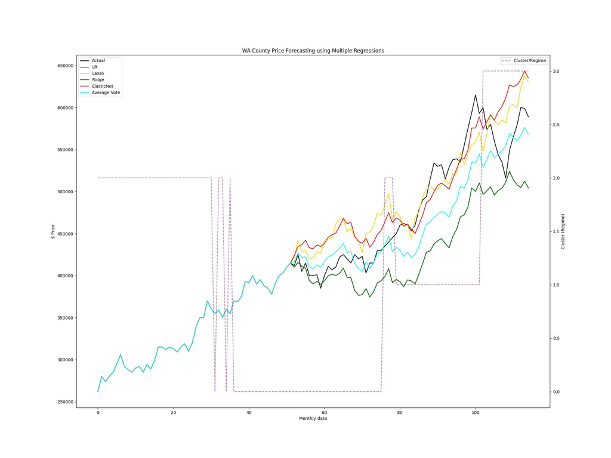

The above plot shows how each model played out till 7/23, along with an average vote model (which is exactly as it sounds the averaging the forecasts of all the models). We see that there really is no consistent “winning” model. It seems that each model (including the average vote) has periods of strength. This is could be seen as somewhat of a positive sign that the dynamically weighted model may perform well.

### Creating the Dynamically weighted model

Knowing the performance of each model in particular regimes we then create a dynamically weighted model. This model dynamically weights the forecast based on individual model performance within the regime which is identified using our K-means model.The weights are calculated using the inverse (and normalized) of the model MSE’s within that regime which was found earlier. Higher weighting was allotted to the models which have a lower MSE score within that particular regime. Doing so we come up with a weight matrix per regime as shown below.

```
##    Regime        LR     Lasso     Ridge        En
## 0       0  0.329756  0.162955  0.331262  0.176027
## 1       1  0.029210  0.395362  0.029246  0.546182
## 2       2  0.200109  0.166491  0.201231  0.432169
## 3       3  0.148219  0.446220  0.148320  0.257241
```

We then test out how our models would perform in the final testing period 8/23 to 7/24. We have all 4 regression models, the average weight model, and the dynamically weighted model plots shown below. Keep in mind the reason the blue curve is shorter than the others are because in order for it to be calculated it required weights per identified regime. In order to come up with the weights, we needed to evaluate performance (both regression, and K-means models) in the initial testing period (11/16-7/23). We now see how all models performed for the remaining data (8/23-7/24) as shown below.

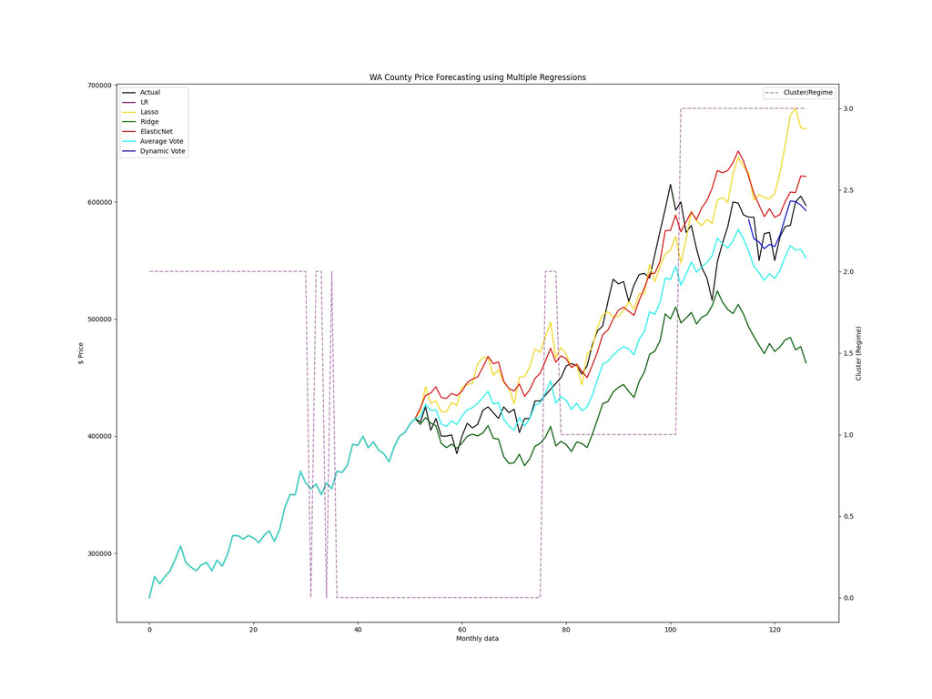

Taking a closer look it is quite clear that the dynamically weighted model did outperform the other models.

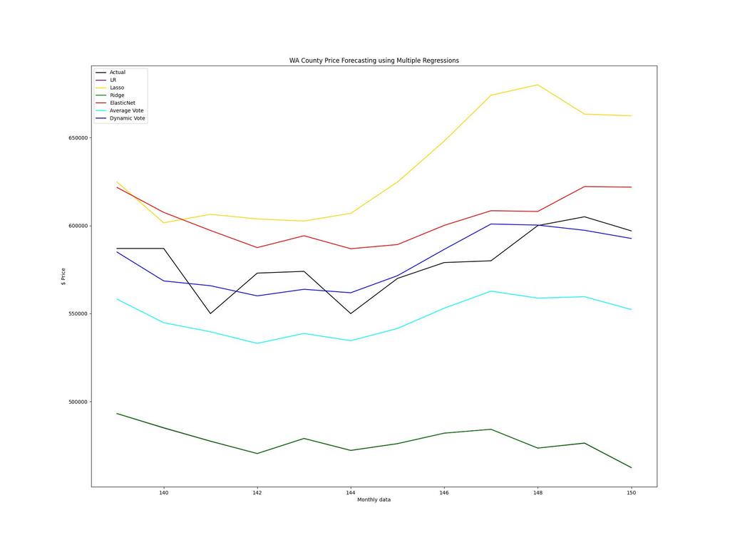

Below we see the MSE and actual forecasts from all of the models during the final testing period.

```
##      Model           MSE
## 0       LR  10669.119026
## 1    Lasso   3374.741259
## 2    Ridge  10650.111744
## 3       En    702.579553
## 4  Average   1110.030327
## 5  Dynamic    131.576863
```

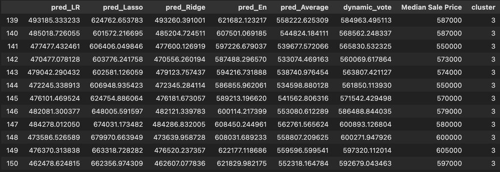

## Conclusion

We see that the term “wisdom of the crowd” makes sense for this particular project. During the final test set forecasting (8/23 to 7/24) we see that the dynamically weighted model outperforms all other models both visually and according to MSE. Linear and Ridge Regression seem to have had one to many at trivia night and the model’s forecasting isn’t particularly coherent, however this is captured in the dynamically weighted model by limiting their forecasting weights. During the final testing period the regime was consistently identified as being regime 3 through our K-Means model. And historically during regime 3, the best performing models were Lasso and Elastic Net which got higher weighting (around 70%) compared to Linear and Ridge Regressions (less than 30%). Overall, it seems a dynamically weighted model plays out nicely.